# Predict Citibike Rides

```r
library(tidyverse)
library(lubridate)

trips_per_day <- read.table('trips_per_day.tsv', header = TRUE)
trips_per_day
```

| ymd | num_trips | date | prcp | snwd | snow | tmax | tmin |
| --- | --- | --- | --- | --- | --- | --- | --- |
| 2014-01-01 | 6059 | 20140101 | 0.00 | 0.0 | 0.0 | 3.3 | 2.4 |
| 2014-01-02 | 8600 | 20140102 | 0.33 | 0.0 | 3.1 | 3.3 | 1.8 |
| 2014-01-03 | 1144 | 20140103 | 0.29 | 5.9 | 3.3 | 1.8 | 0.9 |
| 2014-01-04 | 2292 | 20140104 | 0.00 | 5.9 | 0.0 | 2.9 | 0.8 |
| 2014-01-05 | 2678 | 20140105 | 0.14 | 3.9 | 0.0 | 4.0 | 2.7 |
| 2014-01-06 | 9510 | 20140106 | 0.36 | 1.2 | 0.0 | 5.5 | 1.9 |
| 2014-01-07 | 6267 | 20140107 | 0.00 | 0.0 | 0.0 | 1.9 | 0.4 |
| 2014-01-08 | 9246 | 20140108 | 0.00 | 0.0 | 0.0 | 2.2 | 0.9 |
| 2014-01-09 | 13354 | 20140109 | 0.00 | 0.0 | 0.0 | 3.2 | 2.2 |
| 2014-01-10 | 9847 | 20140110 | 0.11 | 0.0 | 0.0 | 3.7 | 3.0 |

[output cut: 355 more lines]

```r
#Updating my dataframe to include additional features
#Feature for month, day and and weekend
library(lubridate)
trips_per_day %>% select(ymd, date)
```

| ymd | date |
| --- | --- |
| 2014-01-01 | 20140101 |
| 2014-01-02 | 20140102 |
| 2014-01-03 | 20140103 |
| 2014-01-04 | 20140104 |
| 2014-01-05 | 20140105 |
| 2014-01-06 | 20140106 |
| 2014-01-07 | 20140107 |
| 2014-01-08 | 20140108 |
| 2014-01-09 | 20140109 |
| 2014-01-10 | 20140110 |

[output cut: 355 more lines]

```r
# this creates columns to indicate day of week, month and if it's a weekend or not
trips_per_day <-
  trips_per_day %>%
  mutate(month = as.factor(month(ymd)), day_of_week = as.factor(wday(ymd))) %>%
  mutate(weekend = ifelse(day_of_week == 1 | day_of_week == 7, 1, 0)) %>%
  mutate(is_rain = ifelse(prcp > 0.5, 1, 0)) %>%
  mutate(temp_diff = tmax - tmin) %>%
  mutate(is_snwd = ifelse(snwd > 5, 1, 0)) %>%
  mutate(avg_temp = (tmin+tmax)/2) %>%
  mutate(season = case_when(
    (month >=6 & month <= 8) ~ 'Summer',
    (month >= 3 & month <= 5) ~ 'Spring',
    (month >= 9 & month <= 11) ~ 'Fall',
    ( month <= 2) ~ 'Winter'
  ))
```

[output not shown]

```r
trips_per_day
```

| ymd | num_trips | date | prcp | snwd | snow | tmax | tmin | month | day_of_week | weekend | is_rain | temp_diff | is_snwd | avg_temp | season |
| --- | --- | --- | --- | --- | --- | --- | --- | --- | --- | --- | --- | --- | --- | --- | --- |
| 2014-01-01 | 6059 | 20140101 | 0.00 | 0.0 | 0.0 | 3.3 | 2.4 | 1 | 4 | 0 | 0 | 0.9 | 0 | 2.85 | NA |
| 2014-01-02 | 8600 | 20140102 | 0.33 | 0.0 | 3.1 | 3.3 | 1.8 | 1 | 5 | 0 | 0 | 1.5 | 0 | 2.55 | NA |
| 2014-01-03 | 1144 | 20140103 | 0.29 | 5.9 | 3.3 | 1.8 | 0.9 | 1 | 6 | 0 | 0 | 0.9 | 1 | 1.35 | NA |
| 2014-01-04 | 2292 | 20140104 | 0.00 | 5.9 | 0.0 | 2.9 | 0.8 | 1 | 7 | 1 | 0 | 2.1 | 1 | 1.85 | NA |
| 2014-01-05 | 2678 | 20140105 | 0.14 | 3.9 | 0.0 | 4.0 | 2.7 | 1 | 1 | 1 | 0 | 1.3 | 0 | 3.35 | NA |
| 2014-01-06 | 9510 | 20140106 | 0.36 | 1.2 | 0.0 | 5.5 | 1.9 | 1 | 2 | 0 | 0 | 3.6 | 0 | 3.70 | NA |
| 2014-01-07 | 6267 | 20140107 | 0.00 | 0.0 | 0.0 | 1.9 | 0.4 | 1 | 3 | 0 | 0 | 1.5 | 0 | 1.15 | NA |
| 2014-01-08 | 9246 | 20140108 | 0.00 | 0.0 | 0.0 | 2.2 | 0.9 | 1 | 4 | 0 | 0 | 1.3 | 0 | 1.55 | NA |
| 2014-01-09 | 13354 | 20140109 | 0.00 | 0.0 | 0.0 | 3.2 | 2.2 | 1 | 5 | 0 | 0 | 1.0 | 0 | 2.70 | NA |
| 2014-01-10 | 9847 | 20140110 | 0.11 | 0.0 | 0.0 | 3.7 | 3.0 | 1 | 6 | 0 | 0 | 0.7 | 0 | 3.35 | NA |

[output cut: 355 more lines]

```r
NA
```

After doing data wrangling outside, joining the holidays file

```r
library(readr)
holidays <- read_delim("holidays.csv", "\t",
    escape_double = FALSE, col_names = FALSE)
holidays <-
  holidays %>%
  rename(
    holiday_num = X1,
    ymd = X2,
    holiday = X3
  )

holidays <-
  holidays %>%
  mutate(ymd = as.character(ymd))

holidays
```

| holiday_num | ymd | holiday |
| --- | --- | --- |
| 1 | 2012-01-02 | New Year Day |
| 2 | 2012-01-16 | Martin Luther King Jr. Day |
| 3 | 2012-02-20 | Presidents Day (Washingtons Birthday) |
| 4 | 2012-05-28 | Memorial Day |
| 5 | 2012-07-04 | Independence Day |
| 6 | 2012-09-03 | Labor Day |
| 7 | 2012-10-08 | Columbus Day |
| 8 | 2012-11-12 | Veterans Day |
| 9 | 2012-11-22 | Thanksgiving Day |
| 10 | 2012-12-25 | Christmas Day |

[output cut: 80 more lines]

```r
NA
```

Join the holiday data and create a column for whether a day is a holiday or not

```r
trips_per_day <-
  trips_per_day %>%
  left_join(holidays)
trips_per_day
```

| ymd | num_trips | date | prcp | snwd | snow | tmax | tmin | month | day_of_week | weekend | is_rain | temp_diff | is_snwd | avg_temp | holiday_num | holiday |
| --- | --- | --- | --- | --- | --- | --- | --- | --- | --- | --- | --- | --- | --- | --- | --- | --- |
| 2014-01-01 | 6059 | 20140101 | 0.00 | 0.0 | 0.0 | 3.3 | 2.4 | 1 | 4 | 0 | 0 | 0.9 | 0 | 2.85 | 21 | New Year Day |
| 2014-01-02 | 8600 | 20140102 | 0.33 | 0.0 | 3.1 | 3.3 | 1.8 | 1 | 5 | 0 | 0 | 1.5 | 0 | 2.55 | NA | NA |
| 2014-01-03 | 1144 | 20140103 | 0.29 | 5.9 | 3.3 | 1.8 | 0.9 | 1 | 6 | 0 | 0 | 0.9 | 1 | 1.35 | NA | NA |
| 2014-01-04 | 2292 | 20140104 | 0.00 | 5.9 | 0.0 | 2.9 | 0.8 | 1 | 7 | 1 | 0 | 2.1 | 1 | 1.85 | NA | NA |
| 2014-01-05 | 2678 | 20140105 | 0.14 | 3.9 | 0.0 | 4.0 | 2.7 | 1 | 1 | 1 | 0 | 1.3 | 0 | 3.35 | NA | NA |
| 2014-01-06 | 9510 | 20140106 | 0.36 | 1.2 | 0.0 | 5.5 | 1.9 | 1 | 2 | 0 | 0 | 3.6 | 0 | 3.70 | NA | NA |
| 2014-01-07 | 6267 | 20140107 | 0.00 | 0.0 | 0.0 | 1.9 | 0.4 | 1 | 3 | 0 | 0 | 1.5 | 0 | 1.15 | NA | NA |
| 2014-01-08 | 9246 | 20140108 | 0.00 | 0.0 | 0.0 | 2.2 | 0.9 | 1 | 4 | 0 | 0 | 1.3 | 0 | 1.55 | NA | NA |
| 2014-01-09 | 13354 | 20140109 | 0.00 | 0.0 | 0.0 | 3.2 | 2.2 | 1 | 5 | 0 | 0 | 1.0 | 0 | 2.70 | NA | NA |
| 2014-01-10 | 9847 | 20140110 | 0.11 | 0.0 | 0.0 | 3.7 | 3.0 | 1 | 6 | 0 | 0 | 0.7 | 0 | 3.35 | NA | NA |

[output cut: 355 more lines]

```r
# create a column for whether a day is a holiday or not
trips_per_day <-
  trips_per_day %>%
  mutate(holiday = ifelse(!is.na(holiday), 1, 0))

trips_per_day
```

| ymd | num_trips | date | prcp | snwd | snow | tmax | tmin | month | day_of_week | weekend | is_rain | temp_diff | is_snwd | avg_temp | holiday_num | holiday |
| --- | --- | --- | --- | --- | --- | --- | --- | --- | --- | --- | --- | --- | --- | --- | --- | --- |
| 2014-01-01 | 6059 | 20140101 | 0.00 | 0.0 | 0.0 | 3.3 | 2.4 | 1 | 4 | 0 | 0 | 0.9 | 0 | 2.85 | 21 | 1 |
| 2014-01-02 | 8600 | 20140102 | 0.33 | 0.0 | 3.1 | 3.3 | 1.8 | 1 | 5 | 0 | 0 | 1.5 | 0 | 2.55 | NA | 0 |
| 2014-01-03 | 1144 | 20140103 | 0.29 | 5.9 | 3.3 | 1.8 | 0.9 | 1 | 6 | 0 | 0 | 0.9 | 1 | 1.35 | NA | 0 |
| 2014-01-04 | 2292 | 20140104 | 0.00 | 5.9 | 0.0 | 2.9 | 0.8 | 1 | 7 | 1 | 0 | 2.1 | 1 | 1.85 | NA | 0 |
| 2014-01-05 | 2678 | 20140105 | 0.14 | 3.9 | 0.0 | 4.0 | 2.7 | 1 | 1 | 1 | 0 | 1.3 | 0 | 3.35 | NA | 0 |
| 2014-01-06 | 9510 | 20140106 | 0.36 | 1.2 | 0.0 | 5.5 | 1.9 | 1 | 2 | 0 | 0 | 3.6 | 0 | 3.70 | NA | 0 |
| 2014-01-07 | 6267 | 20140107 | 0.00 | 0.0 | 0.0 | 1.9 | 0.4 | 1 | 3 | 0 | 0 | 1.5 | 0 | 1.15 | NA | 0 |
| 2014-01-08 | 9246 | 20140108 | 0.00 | 0.0 | 0.0 | 2.2 | 0.9 | 1 | 4 | 0 | 0 | 1.3 | 0 | 1.55 | NA | 0 |
| 2014-01-09 | 13354 | 20140109 | 0.00 | 0.0 | 0.0 | 3.2 | 2.2 | 1 | 5 | 0 | 0 | 1.0 | 0 | 2.70 | NA | 0 |
| 2014-01-10 | 9847 | 20140110 | 0.11 | 0.0 | 0.0 | 3.7 | 3.0 | 1 | 6 | 0 | 0 | 0.7 | 0 | 3.35 | NA | 0 |

[output cut: 355 more lines]

```r
NA
```

## Split the data

Now split the data 80% for training the model 10% for validation 10% for final test set Reference used: https://stackoverflow.com/questions/36068963/r-how-to-split-a-data-frame-into-training-validation-and-test-sets

```r
set.seed(2)

num_days <- nrow(trips_per_day)
# set out the the fractions that you need to train
frac_train <- 0.8
frac_validation <- 0.1
frac_test <- 0.1

# compute sample sizes
sample_size_train <- floor(num_days * frac_train)
sample_size_validation <- floor(num_days * frac_validation)
sample_size_test <- floor(num_days * frac_test)

# randomly sample rows for the training set without replacement - he named this ndx
indices_traning <- sample(1:num_days, sample_size_train, replace = FALSE)

# setdiff() used to avoid overlapping subsets of indices
indices_not_training <- setdiff(seq_len(num_days), indices_traning)

# now to find the validation and test indices
indices_validation <- sample(indices_not_training, size = sample_size_validation)
indices_test <- setdiff(indices_not_training, indices_validation)


# used to fit the model
trips_per_day_train <- trips_per_day[indices_traning, ]
trips_per_day_validate <- trips_per_day[indices_validation, ]

# Restricted access - don't look!
trips_per_day_test <- trips_per_day[indices_test, ]

# we can see the rest of the data
trips_per_day_train
```

|  | ymd | num_trips | date | prcp | snwd | snow | tmax | tmin | month | day_of_week | weekend | is_rain | temp_diff | is_snwd | avg_temp | holiday_num | holiday |
| --- | --- | --- | --- | --- | --- | --- | --- | --- | --- | --- | --- | --- | --- | --- | --- | --- | --- |
| 341 | 2014-12-07 | 9319 | 20141207 | 0.04 | 0.0 | 0.0 | 4.2 | 3.0 | 12 | 1 | 1 | 0 | 1.2 | 0 | 3.60 | NA | 0 |
| 198 | 2014-07-17 | 38619 | 20140717 | 0.00 | 0.0 | 0.0 | 8.1 | 6.7 | 7 | 5 | 0 | 0 | 1.4 | 0 | 7.40 | NA | 0 |
| 262 | 2014-09-19 | 35674 | 20140919 | 0.00 | 0.0 | 0.0 | 6.6 | 5.4 | 9 | 6 | 0 | 0 | 1.2 | 0 | 6.00 | NA | 0 |
| 273 | 2014-09-30 | 34901 | 20140930 | 0.00 | 0.0 | 0.0 | 7.1 | 6.2 | 9 | 3 | 0 | 0 | 0.9 | 0 | 6.65 | NA | 0 |
| 349 | 2014-12-15 | 17761 | 20141215 | 0.00 | 0.0 | 0.0 | 4.8 | 3.7 | 12 | 2 | 0 | 0 | 1.1 | 0 | 4.25 | NA | 0 |
| 204 | 2014-07-23 | 34173 | 20140723 | 0.19 | 0.0 | 0.0 | 8.8 | 7.2 | 7 | 4 | 0 | 0 | 1.6 | 0 | 8.00 | NA | 0 |
| 297 | 2014-10-24 | 29606 | 20141024 | 0.00 | 0.0 | 0.0 | 6.3 | 5.1 | 10 | 6 | 0 | 0 | 1.2 | 0 | 5.70 | NA | 0 |
| 178 | 2014-06-27 | 35823 | 20140627 | 0.00 | 0.0 | 0.0 | 8.3 | 6.7 | 6 | 6 | 0 | 0 | 1.6 | 0 | 7.50 | NA | 0 |
| 75 | 2014-03-16 | 9851 | 20140316 | 0.00 | 0.0 | 0.0 | 4.2 | 3.0 | 3 | 1 | 1 | 0 | 1.2 | 0 | 3.60 | NA | 0 |
| 131 | 2014-05-11 | 28326 | 20140511 | 0.03 | 0.0 | 0.0 | 8.2 | 6.0 | 5 | 1 | 1 | 0 | 2.2 | 0 | 7.10 | NA | 0 |

[output cut: 282 more lines]

```r
trips_per_day_validate
```

|  | ymd | num_trips | date | prcp | snwd | snow | tmax | tmin | month | day_of_week | weekend | is_rain | temp_diff | is_snwd | avg_temp | holiday_num | holiday |
| --- | --- | --- | --- | --- | --- | --- | --- | --- | --- | --- | --- | --- | --- | --- | --- | --- | --- |
| 64 | 2014-03-05 | 13801 | 20140305 | 0.00 | 3.9 | 0 | 3.9 | 2.6 | 3 | 4 | 0 | 0 | 1.3 | 0 | 3.25 | NA | 0 |
| 249 | 2014-09-06 | 26808 | 20140906 | 0.11 | 0.0 | 0 | 9.1 | 6.7 | 9 | 7 | 1 | 0 | 2.4 | 0 | 7.90 | NA | 0 |
| 287 | 2014-10-14 | 30252 | 20141014 | 0.00 | 0.0 | 0 | 7.6 | 6.3 | 10 | 3 | 0 | 0 | 1.3 | 0 | 6.95 | NA | 0 |
| 235 | 2014-08-23 | 26429 | 20140823 | 0.01 | 0.0 | 0 | 7.7 | 6.7 | 8 | 7 | 1 | 0 | 1.0 | 0 | 7.20 | NA | 0 |
| 52 | 2014-02-21 | 8680 | 20140221 | 0.09 | 13.0 | 0 | 4.9 | 3.6 | 2 | 6 | 0 | 0 | 1.3 | 1 | 4.25 | NA | 0 |
| 268 | 2014-09-25 | 17165 | 20140925 | 0.32 | 0.0 | 0 | 6.4 | 5.7 | 9 | 5 | 0 | 0 | 0.7 | 0 | 6.05 | NA | 0 |
| 73 | 2014-03-14 | 16299 | 20140314 | 0.00 | 0.0 | 0 | 4.6 | 2.2 | 3 | 6 | 0 | 0 | 2.4 | 0 | 3.40 | NA | 0 |
| 345 | 2014-12-11 | 16413 | 20141211 | 0.01 | 1.2 | 0 | 3.8 | 3.1 | 12 | 5 | 0 | 0 | 0.7 | 0 | 3.45 | NA | 0 |
| 119 | 2014-04-29 | 18404 | 20140429 | 0.03 | 0.0 | 0 | 5.2 | 4.3 | 4 | 3 | 0 | 0 | 0.9 | 0 | 4.75 | NA | 0 |
| 295 | 2014-10-22 | 12023 | 20141022 | 1.51 | 0.0 | 0 | 5.8 | 5.0 | 10 | 4 | 0 | 1 | 0.8 | 0 | 5.40 | NA | 0 |

[output cut: 26 more lines]

```r
NA
NA
NA
```

## Let’s get to modeling

Start out with the model in that notebook, which uses only the minimum temperature on each day to predict the number of trips taken that day. Try different polynomial degrees in the minimum temperature and check that you get results similar to what’s in that notebook, although they likely won’t be identical due to shuffling of which days end up in the train, validation, and test splits. Quantify your performance using root mean-squared error.

Now we try plottign minimum temperature with the number of trips for different polynomial degrees

```r
# fitting a model for each polynomial degree
degree <- 1:8

# set the vectors to hold the training and validation errors
train_err <- c()
validate_err <- c()

for(deg in degree){

  # fit on training data
  model <- lm(num_trips ~ poly(tmin, deg, raw =TRUE), data = trips_per_day_train)

  #par(mfrow= c(2,2))
  #plot(model)

  # using mean squared error
  # evaluate on training data
  train_err[deg] <- sqrt(mean((predict(model, trips_per_day_train) - trips_per_day_train$num_trips)^2))

  #evaluate on validate data
  validate_err[deg] <- sqrt(mean((predict(model, trips_per_day_validate) - trips_per_day_validate$num_trips)^2))


}

train_err
```

```
[1] 5672.018 5669.764 5492.339 5456.544 5443.149 5440.786
[7] 5431.886 5422.747
```

```r
validate_err
```

```
[1] 6387.879 6392.383 6190.700 6112.906 6062.094 6052.749
[7] 6040.143 6082.021
```

Now to plot the two errors together Note for me: Gather takes multiple columns and collapses into key-value pairs, duplicating all other columns as needed. You use gather() when you notice that you have columns that are not variables.

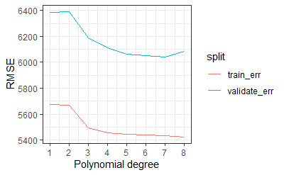

```r
# this takes the degrees and separates the training and validation error
plot_data <-
  data.frame(degree, train_err, validate_err) %>%
  gather("split", "error", -degree)

# Now let's plot
plot_data %>%
  ggplot(aes(x=degree, y= error, color = split)) +
  geom_line() +
  scale_x_continuous(breaks = degree) +
  xlab("Polynomial degree") +
  ylab("RMSE")
```

```r
NA
NA
```

Now to fit the data and the model together. I choose the 4th degree polynomial to stay on the safe side and not do overfitting

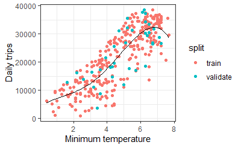

```r
library(dplyr)
library(modelr)
library(broom)

model <- lm(num_trips ~ poly(tmin, 4, raw = T), data = trips_per_day_train)

trips_per_day_train <-
  trips_per_day_train %>%
  add_predictions(model) %>%
  mutate(split = "train")

trips_per_day_validate <-
  trips_per_day_validate %>%
  add_predictions(model) %>%
  mutate(split = "validate")

plot_data <- bind_rows(trips_per_day_train, trips_per_day_validate)


plot_data %>%
ggplot(aes(x = tmin, y = num_trips)) +
  geom_point(aes(color = split)) +
  geom_line(aes(y = pred)) +
  xlab('Minimum temperature') +
  ylab('Daily trips') +
  scale_y_continuous()
```

```r
trips_per_day_train
```

| ymd | num_trips | date | prcp | snwd | snow | tmax | tmin | month | day_of_week | weekend | is_rain | temp_diff | is_snwd | avg_temp | holiday_num | holiday | pred | split |
| --- | --- | --- | --- | --- | --- | --- | --- | --- | --- | --- | --- | --- | --- | --- | --- | --- | --- | --- |
| 2014-12-07 | 9319 | 20141207 | 0.04 | 0.0 | 0.0 | 4.2 | 3.0 | 12 | 1 | 1 | 0 | 1.2 | 0 | 3.60 | NA | 0 | 12444.763 | train |
| 2014-07-17 | 38619 | 20140717 | 0.00 | 0.0 | 0.0 | 8.1 | 6.7 | 7 | 5 | 0 | 0 | 1.4 | 0 | 7.40 | NA | 0 | 32289.683 | train |
| 2014-09-19 | 35674 | 20140919 | 0.00 | 0.0 | 0.0 | 6.6 | 5.4 | 9 | 6 | 0 | 0 | 1.2 | 0 | 6.00 | NA | 0 | 26912.161 | train |
| 2014-09-30 | 34901 | 20140930 | 0.00 | 0.0 | 0.0 | 7.1 | 6.2 | 9 | 3 | 0 | 0 | 0.9 | 0 | 6.65 | NA | 0 | 31114.031 | train |
| 2014-12-15 | 17761 | 20141215 | 0.00 | 0.0 | 0.0 | 4.8 | 3.7 | 12 | 2 | 0 | 0 | 1.1 | 0 | 4.25 | NA | 0 | 15892.086 | train |
| 2014-07-23 | 34173 | 20140723 | 0.19 | 0.0 | 0.0 | 8.8 | 7.2 | 7 | 4 | 0 | 0 | 1.6 | 0 | 8.00 | NA | 0 | 31637.606 | train |
| 2014-10-24 | 29606 | 20141024 | 0.00 | 0.0 | 0.0 | 6.3 | 5.1 | 10 | 6 | 0 | 0 | 1.2 | 0 | 5.70 | NA | 0 | 24950.808 | train |
| 2014-06-27 | 35823 | 20140627 | 0.00 | 0.0 | 0.0 | 8.3 | 6.7 | 6 | 6 | 0 | 0 | 1.6 | 0 | 7.50 | NA | 0 | 32289.683 | train |
| 2014-03-16 | 9851 | 20140316 | 0.00 | 0.0 | 0.0 | 4.2 | 3.0 | 3 | 1 | 1 | 0 | 1.2 | 0 | 3.60 | NA | 0 | 12444.763 | train |
| 2014-05-11 | 28326 | 20140511 | 0.03 | 0.0 | 0.0 | 8.2 | 6.0 | 5 | 1 | 1 | 0 | 2.2 | 0 | 7.10 | NA | 0 | 30270.986 | train |

[output cut: 282 more lines]

```r
rmse(model, plot_data)
```

```
[1] 5532.39
```

```r
tidy(model)
glance(model)
```

[output not shown]

Let’s see what we’re working with I keep forgetting

```r
colnames(trips_per_day)
```

[output not shown]

## Weather model: Model 1: This model looks at effects of weather alone with precipitation, snow, maximum temperature and minimum temperature

```r
rmse(weather_model, trips_per_day_validate)
```

```
[1] 4526.466
```

To evaluate the performance of the model.

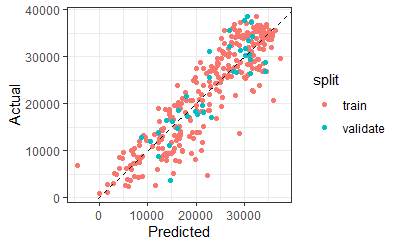

```r
trips_per_day_train <-
  trips_per_day_train %>%
  add_predictions(weather_model) %>%
  mutate(split = "train")

trips_per_day_validate <-
  trips_per_day_validate %>%
  add_predictions(weather_model) %>%
  mutate(split = "validate")

plot_data <- bind_rows(trips_per_day_train, trips_per_day_validate)

plot_data %>%
  ggplot(aes(x=pred, y=num_trips)) +
  geom_point(aes(color=split)) +
  geom_abline(linetype = "dashed") +
  xlab("Predicted") +
  ylab("Actual")
```

```r
# calculate the rmse - the values don't look too different
rmse(weather_model, trips_per_day_train)
```

```
[1] 4548.263
```

```r
rmse(weather_model, trips_per_day_validate)
```

```
[1] 4526.466
```

```r
rmse(weather_model, plot_data)
```

```
[1] 4545.876
```